# (Ford Gobike Slide Deck)

## by (Abdelrahman Moustafa)

## Investigation Overview

> In this investigation, I wanted to look at the characteristics of trip data that could be used to predict their duration. The main focus was on the five: age, start station, duration, user type, and gender.

## Dataset Overview

> This data set includes information about individual rides made in a bike-sharing system covering the greater San Francisco.  
> Because of the size of the dataset, this research only focuses on the data in 2019.

# Univariate Findings

## (Distribution Of Trip Duration)

> Duration has a long tailed distribution. Most of the bike trips lasts between 8 and 15 minutes. There are a lot of bike trips less than 3 minutes and over 40 minutes

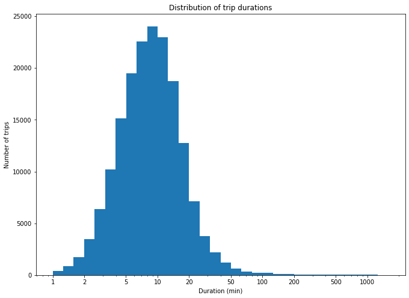

```python
# Logarthmic scale transformation on a histogram
# There's a long tail in the distribution, so let's put it on a log scale instead
log_binsize = 0.1
log_bins = 10 ** np.arange(0, np.log10(df['duration_min'].max()) + log_binsize, log_binsize)

plt.figure(figsize=[11, 8])
plt.hist(data = df, x = 'duration_min', bins = log_bins)
plt.title('Distribution of trip durations')
plt.xlabel('Duration (min)')
plt.ylabel('Number of trips')
plt.xscale('log')
tick_locs = [1, 2, 5, 10, 20, 50, 100, 200, 500, 1000]
plt.xticks(tick_locs, tick_locs)
plt.show()
```

## (User Type)

> Most users are actually subscribers (90.5% of total users) who are using the program more than actual customers who represents only 9.5% of total users.

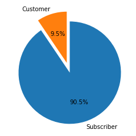

```python
# plot a pie chart
user_category = df['user_type'].value_counts()
plt.pie(user_category, explode =  (.1, .1), labels = user_category.index, startangle = 90,
        counterclock = False, autopct='%1.1f%%')
plt.show()
```

## (Daily Ride Usage)

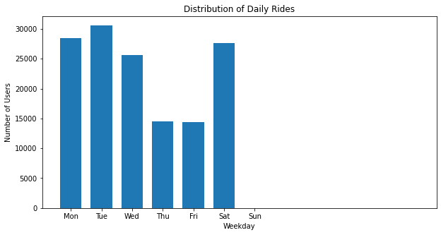

```python
# label to use in plots
weekday_labels = ['Mon', 'Tue', 'Wed', 'Thu', 'Fri', 'Sat', 'Sun']

# plot a histogram with gaps between bars
bin_edges = np.arange(0.5, 12.5 + 1, 1)
plt.figure(figsize=[10,5])
plt.hist(data = df, x = 'start_weekday', bins = bin_edges, rwidth = 0.7)
plt.xticks(np.arange(1, 7 + 1, 1),weekday_labels)
plt.xlabel('start_weekday')
plt.title('Distribution of Daily Rides')
plt.xlabel('Weekday')
plt.ylabel('Number of Users')
plt.show()
```

## (Distribution of start hour)

> The most busy hour is 5 PM, second busy hour is 8 AM. The busy hours are 7-9 AM in morning and 4-6 PM in the evening. This time is common commuting time.

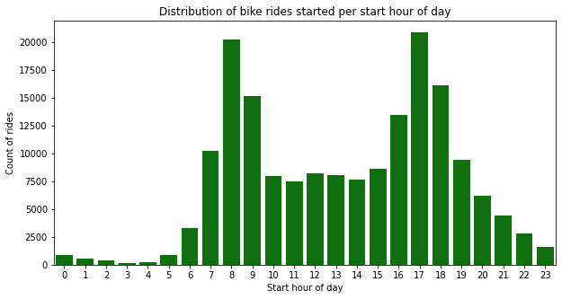

```python
# Plot distribution of start hour
plt.figure(figsize=(10,5))
sb.countplot(data=df, x='start_hour', color='g')
plt.xlabel('Start hour of day')
plt.ylabel('Count of rides')
plt.title('Distribution of bike rides started per start hour of day')
plt.show()
```

## (Gender Distribution)

> Males use the bike service overwhelmily more than females and other genders. Over 120,000 for males.

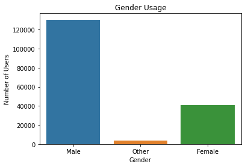

```python
# barplot of gender usage
sb.countplot(data = df, x = 'member_gender')
plt.title('Gender Usage')
plt.xlabel('Gender')
plt.ylabel('Number of Users')
plt.show()
```

## (Age Distribution)

> Most users are between the age 25 and 35.

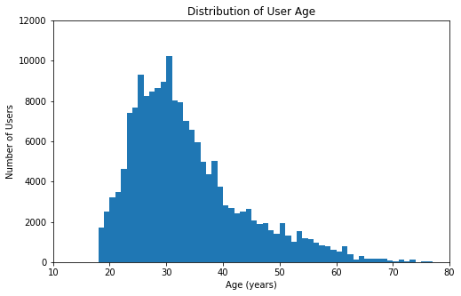

```python
# Plotting age distribution.
binsize = 1
bins = np.arange(0, df['member_birth_year'].astype(float).max()+binsize, binsize)

plt.figure(figsize=[8, 5])
plt.hist(data = df, x = 'member_birth_year', bins = bins)
plt.axis([1939, 2009, 0, 12000])
plt.xticks([1939, 1949, 1959, 1969, 1979, 1989, 1999, 2009], [(2019-1939), (2019-1949), (2019-1959), (2019-1969), (2019-1979), (2019-1989), (2019-1999), (2019-2009)])
plt.gca().invert_xaxis()
plt.title('Distribution of User Age')
plt.xlabel('Age (years)')
plt.ylabel('Number of Users')
plt.show()
```

## (Top 10 start station name)

> As we see here the top 10 start station name and the most start staion is Market St at 10th St, San Francisco Caltrain Station 2

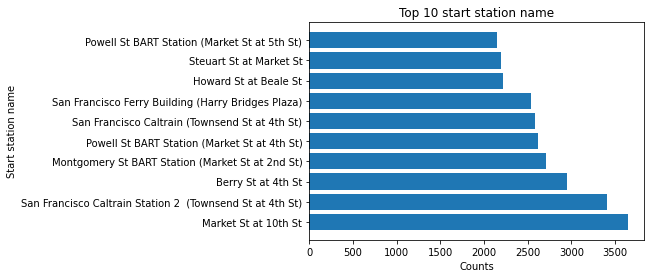

```python
# Finding top 10 start station name
start_station = df.groupby('start_station_name').agg({'start_station_name': 'count'}).rename(columns={'start_station_name': 'counts'}).reset_index().sort_values('counts', ascending=False).head(10)
plt.barh(start_station['start_station_name'], start_station['counts'])
plt.ylabel('Start station name')
plt.xlabel('Counts')
plt.title('Top 10 start station name')
plt.show()
```

# Bivariate Exploration

## (Trip Duration and Age)

> The concentration of rides are for persons between ages 25 and 45 showing the inverse relationship between age and the trip duration.

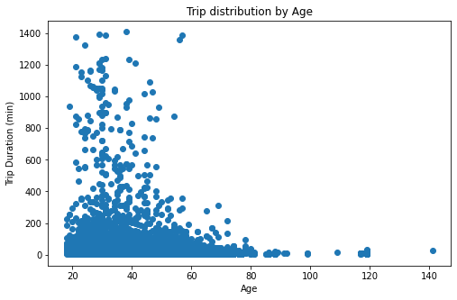

```python
# Add new column for age
df['age'] = (2019 - df.member_birth_year)

# Scatter charts showing distribution between age and trip duration
plt.figure(figsize=[8,5])
plt.scatter(data = df, x = 'age', y ='duration_min', alpha= None)
plt.title('Trip distribution by Age')
plt.xlabel('Age')
plt.ylabel('Trip Duration (min)')
plt.show()
```

## (Trip Duration and Gender)

> The boxplot does show that female and other gender have a higher trip duration than males.

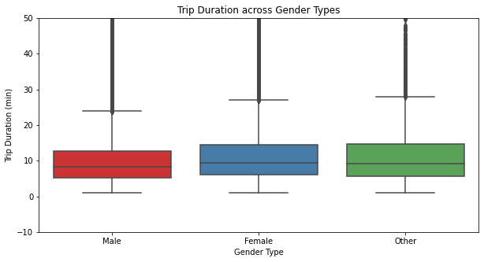

```python
# https://seaborn.pydata.org/generated/seaborn.boxplot.html
# A box plot showing comparisons between quatitative and categorical variables
plt.figure(figsize = [10, 5])
sb.boxplot(x='member_gender', y='duration_min', data = df, palette ='Set1', order=['Male', 'Female', 'Other'])
plt.ylim(-10, 50)
plt.title('Trip Duration across Gender Types')
plt.xlabel('Gender Type')
plt.ylabel('Trip Duration (min)')
plt.show()
```